# Chapter 3

# Organizing, Displaying, and Presenting Data

# Let’s Introduce Some Terms

## Univariate vs. Bivariate

Univariate Statistics involves only one variable.

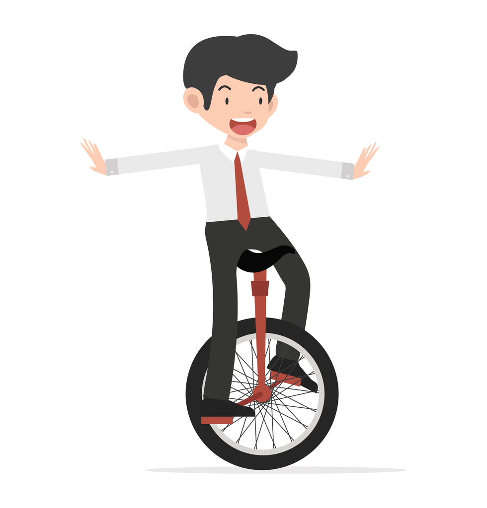

Bivariate Statistics involves only two variables.

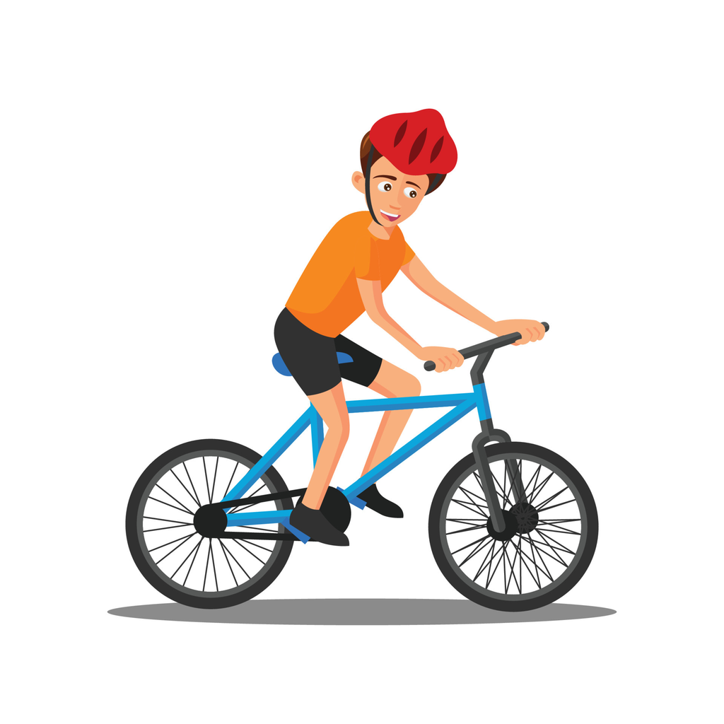

photos by Vecteezy

## Examples of a Univariate Statistic

Frequency distribution

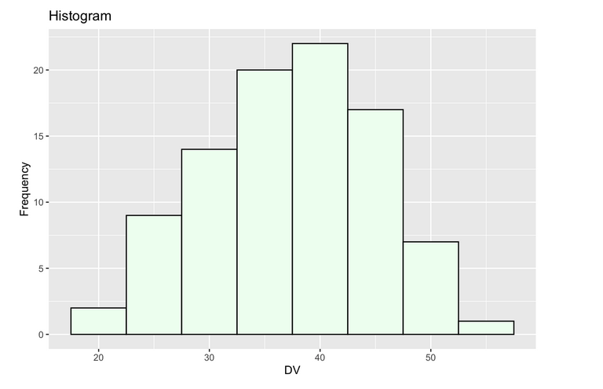

## Examples of a Univariate Statistic

Proportion (p)

$p = f / n$

f = raw frequency

n = total sample size

## Examples of a Univariate Statistic

Percentage (pct)

$p = (f / n)100$

f = raw frequency

n = total sample size

## Examples of a Univariate Statistic

Rate (r)

$r = (f/N)Multiplier$

f = frequency

N = population

Multiplier = determined by our population size (e.g., if your population is millions, you’d use 100,000)

- What would you use if your populations is smaller? For example, a rural town of 15,000.

## Let’s do some calculations

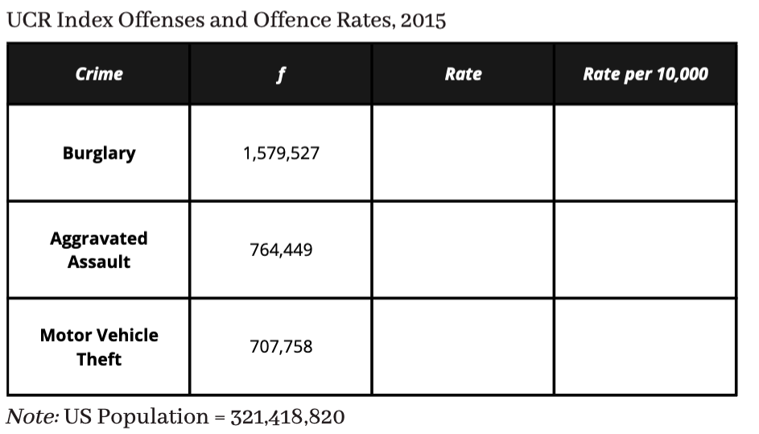

# Examples of a Bivariate Statistics

## Contingency Tables

A table showing overlap between two variables.

The top Columns and furthest left Rows are our variables.

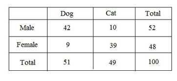

photo by study.com

## Contingency Tables

A table showing overlap between two variables.

Palmer Penguins Count

| Species | female | male |
| --- | --- | --- |
| Adelie | 73 | 73 |
| Chinstrap | 34 | 34 |
| Gentoo | 58 | 61 |

## Recap

- Univariate and Bivariate Statistics
- Proportion, Percents, and Rates
- Contingency Tables

# Graphs and Charts

## Pie Charts

Used for categorical variables with only a few groups.

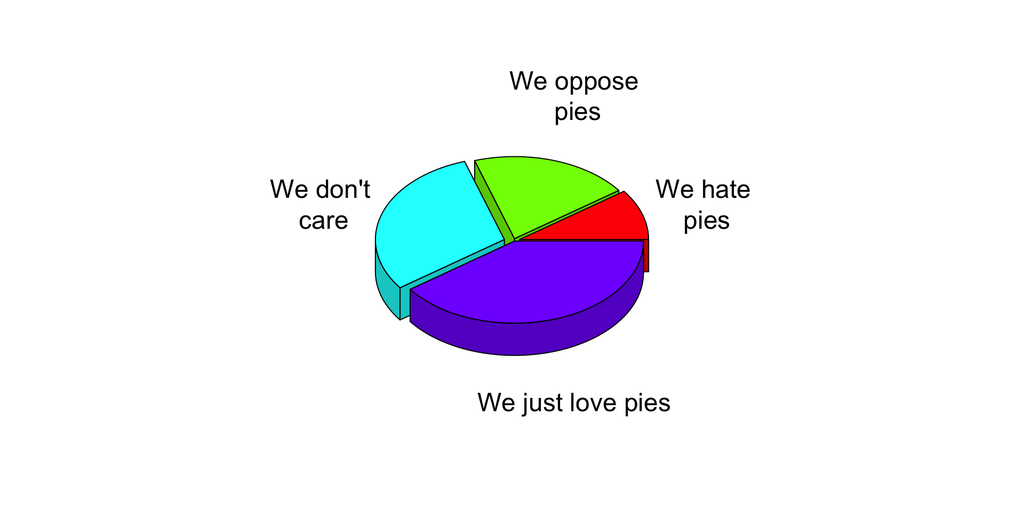

## Adding Data to Pies

Adding percentages to pie charts

[interactive chart not shown]

[RPubs](https://rpubs.com/hari141v/644255)

## Bar Graphs

Used for categorical variables that have many or a few groups.

[interactive chart not shown]

[Plotly](https://plotly.com/r/bar-charts/)

## Histograms

Used for continuous variables

[interactive chart not shown]

[Plotly](https://plotly.com/r/histograms/)

## Frequency Polygon

Used for continuous variables.

Alternative to a histogram.

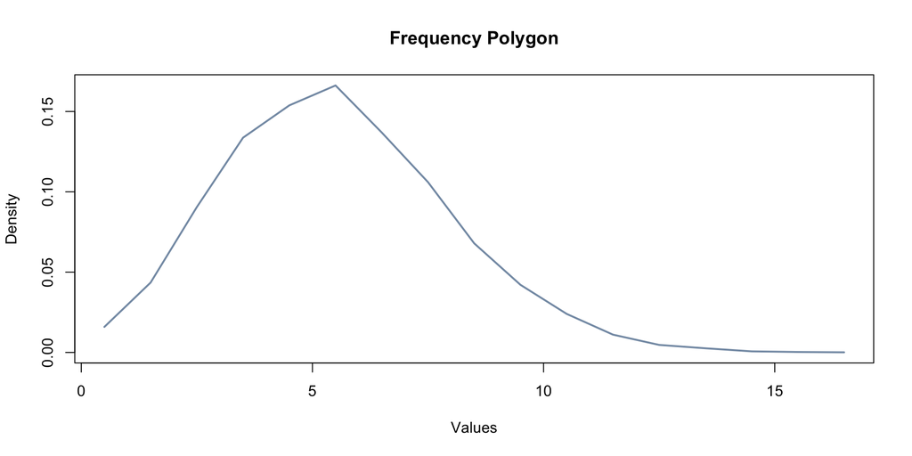

## Line Charts

These are common for longitudinal variables or trends.

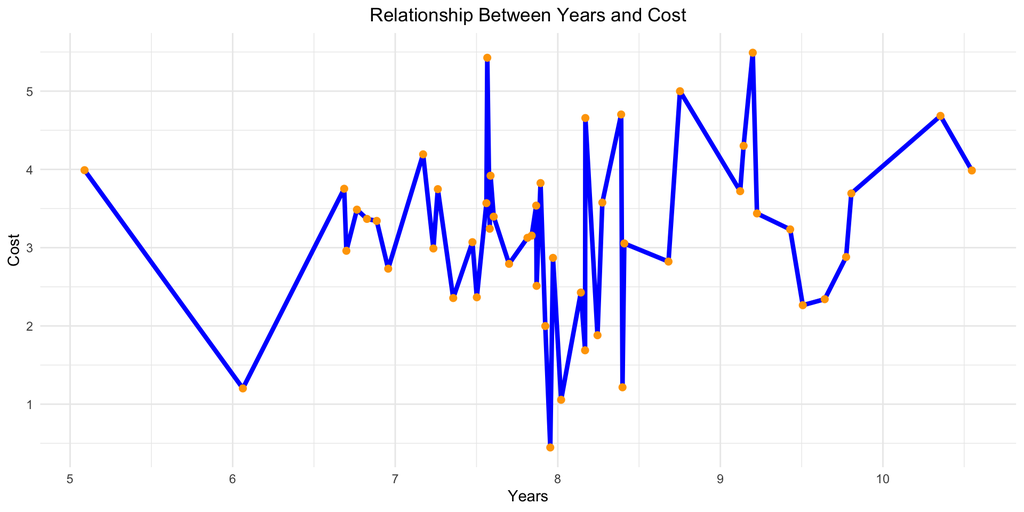

## Pop Quiz

When using categorical graphs, what types of variables can we use?

A.) Ratio and Ordinal  
B.) Interval and Nominal  
C.) Nominal and Ordinal  
D.) None of the above

`01:00`

## Setting up Posit Cloud

1.) [Head to Posit Cloud](https://posit.cloud/)

2.) Click “Get Started”

3.) Under “Cloud Free” click Learn more

4.) Click Sign Up then fill out the form

5.) Verify your email

## Setting up Posit Cloud

6.) Once your in the posit Cloud, click “New Project”

[figure not shown]

## Setting up Posit Cloud

7.) Then “New RStudio Project”

[figure not shown]

## Have a great day

[figure not shown]

Giphy